# Final assignment

Marián Miklós

2018 január 21

## 1. Executive summary and exploratory data analysis

In this analysis, I investigated data from schizophrenic patients. The patients completed the Wisconsin Card Sorting test (WCST), the Stop Signal task and the Raven Progressive Matrices task. The WCST is a test of frontal executive functions (mainly set shifting), the Stop signal task also taps executive functions, mainly behavioural inhibition and the Raven test is a test of fluid intelligence. The aim of the investigation was to shed light on the relationship between performance on the WCST and the Stop Signal task, and also to see whether scores on the WCST correlate to fluid intelligence measured by the Raven test. As a first step, I explored the dataset and described the characteristics of measured variables (missing values, distribution and outliers). Next, I investigated Hypothesis 1, according to which the two WCST subgroups (created by dividing standardized WCST scores by a median split) differ with regards to Raven IQ; more specifically, the higher scoring WCST group was hypothesized to have higher Raven IQ. This assumption was not corroborated, since the independent samples t-test conducted showed no difference between the two groups. According to Hypothesis 2, scores on the WCST correlate negatively with Stop Signal reaction time (the main measure of performance), that is, higher WCST scores would predict faster reaction times. This was also not confirmed by my analysis, as Pearson correlation and the linear regression model were not significant.

## 2. Description of the dataset

Dataset structure

```r
str(SCH_full)
```

```
## Classes 'tbl_df', 'tbl' and 'data.frame':    47 obs. of  5 variables:
##  $ JELIGE    : num  101 102 103 104 105 106 107 108 109 110 ...
##  $ WCST_score: num  68 89 94 117 95 45 75 96 63 59 ...
##  $ WCST_cat  : num  1 2 2 2 2 1 1 2 1 1 ...
##  $ SSRT      : num  275 353 386 424 172 ...
##  $ Raven_IQ  : num  135 84 128 79 95 98 88 114 92 76 ...
```

My dataset contains 47 observations and 5 variables:  
JELIGE  
WCST_score: numerical, standardized performance on the WCST  
WCST_cat: numerical, 1 or 2, 1 meaning lower and 2 meaning higher category based on WCST median  
SSRT: numerical, Stop Signal reaction time, measure of performance in the Stop Signal task  
Raven_IQ: numerical, measure of fluid intelligence

There are no missing values.

Dataset summary

```r
summary(SCH_full)
```

```
##      JELIGE        WCST_score        WCST_cat          SSRT
##  Min.   :101.0   Min.   :  9.00   Min.   :1.000   Min.   :128.3
##  1st Qu.:112.5   1st Qu.: 62.00   1st Qu.:1.000   1st Qu.:283.4
##  Median :128.0   Median : 79.00   Median :1.000   Median :319.2
##  Mean   :220.9   Mean   : 80.13   Mean   :1.404   Mean   :328.2
##  3rd Qu.:142.5   3rd Qu.: 96.50   3rd Qu.:2.000   3rd Qu.:383.1
##  Max.   :804.0   Max.   :133.00   Max.   :2.000   Max.   :539.1
##     Raven_IQ
##  Min.   : 66.00
##  1st Qu.: 83.50
##  Median : 92.00
##  Mean   : 93.96
##  3rd Qu.:102.00
##  Max.   :135.00
```

### 2.1. Distribution and outliers of variable Raven_IQ

Visualizing Raven IQ data to spot outliers

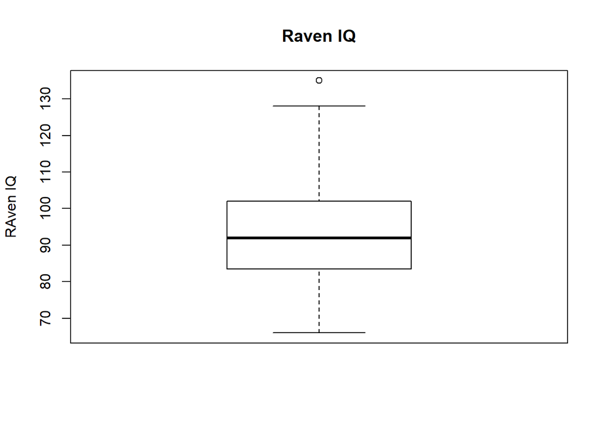

```r
boxplot(SCH_full$Raven_IQ,data=SCH_full, ylab ="RAven IQ", main= "Raven IQ")
```

As we can see, there is one outlier.

Discarding outlier

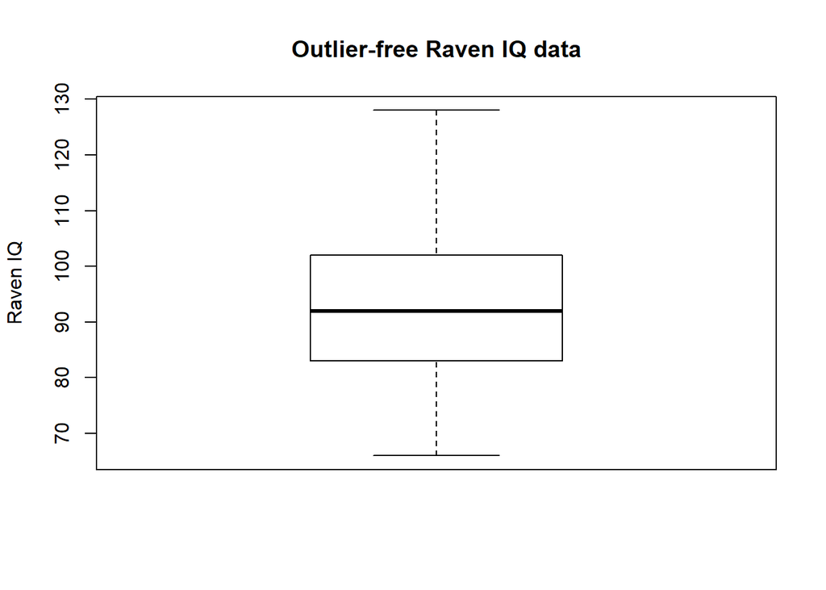

```r
bench <- 102.00 + 1.5*IQR(SCH_full$Raven_IQ)

SCH_Raven <- subset(SCH_full, Raven_IQ<bench)
boxplot(SCH_Raven$Raven_IQ, ylab= "Raven IQ", main="Outlier-free Raven IQ data")
```

Normality of outlier-free Raven_IQ data

```r
shapiro.test(SCH_Raven$Raven_IQ)
```

```
##
##  Shapiro-Wilk normality test
##
## data:  SCH_Raven$Raven_IQ
## W = 0.97708, p-value = 0.492
```

The Raven IQ data is normally distributed (p>0.05).

Visualizing distribution of IQ with normal curve

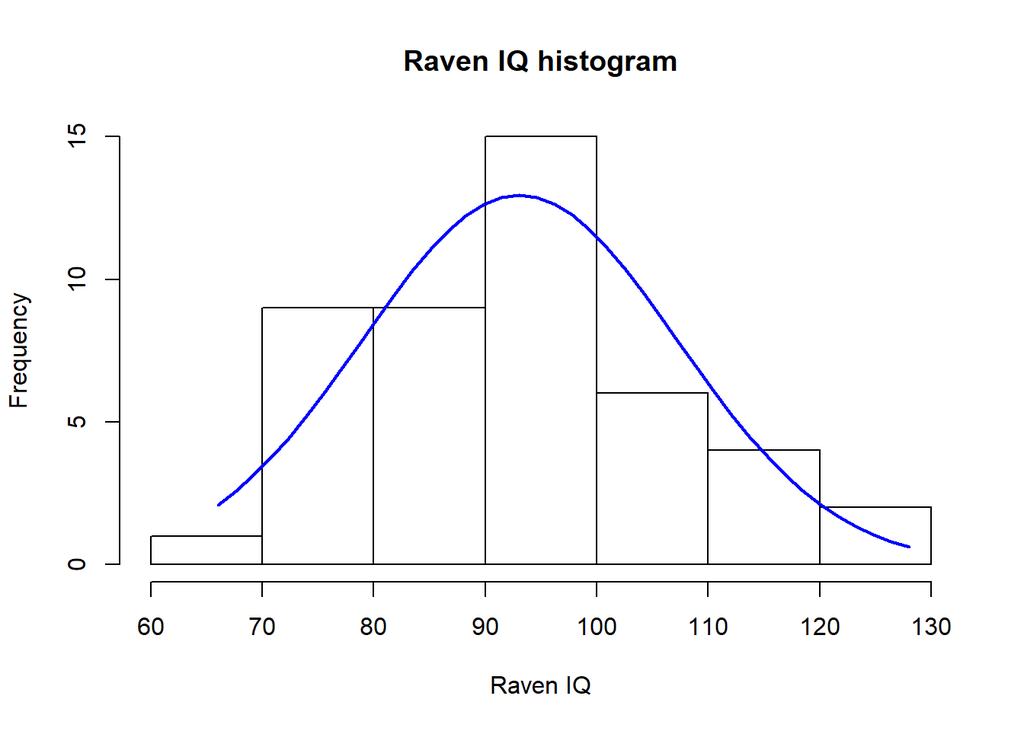

```r
histogram <- hist(SCH_Raven$Raven_IQ, plot=TRUE, main="Raven IQ histogram", xlab="Raven IQ" )
xfit<-seq(min(SCH_Raven$Raven_IQ),max(SCH_Raven$Raven_IQ),length=40)
yfit<-dnorm(xfit,mean=mean(SCH_Raven$Raven_IQ),sd=sd(SCH_Raven$Raven_IQ))
yfit <- yfit*diff(histogram$mids[1:2])*length(SCH_Raven$Raven_IQ)
lines(xfit, yfit, col="blue", lwd=2)
```

Visualizing in a different way: density plot

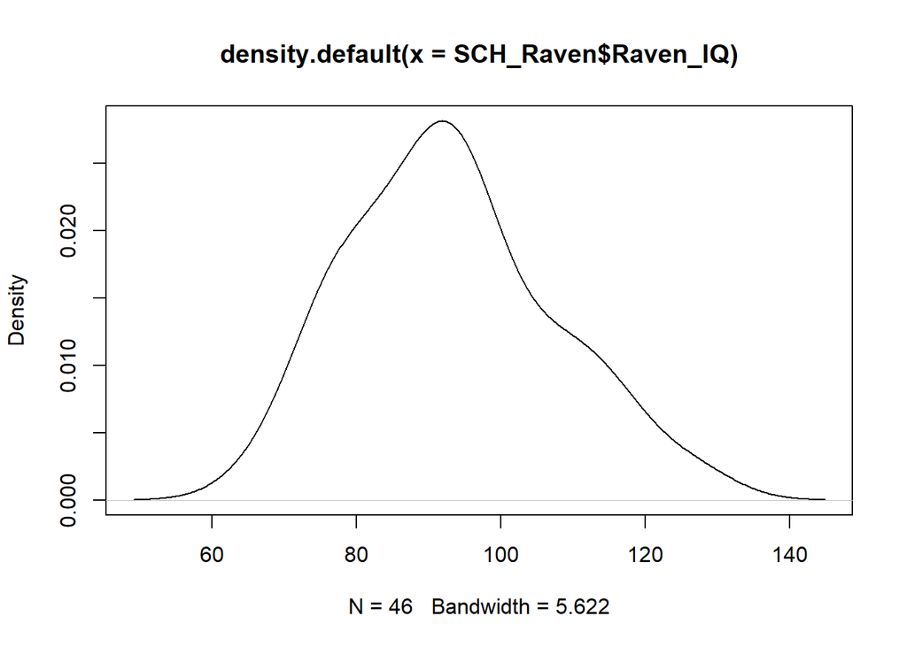

```r
d <- density(SCH_Raven$Raven_IQ)
plot(d)
```

### 2.2. Distributions and outliers of variables WCST_score and SSRT

Visualizing WCST_score outliers in boxplot

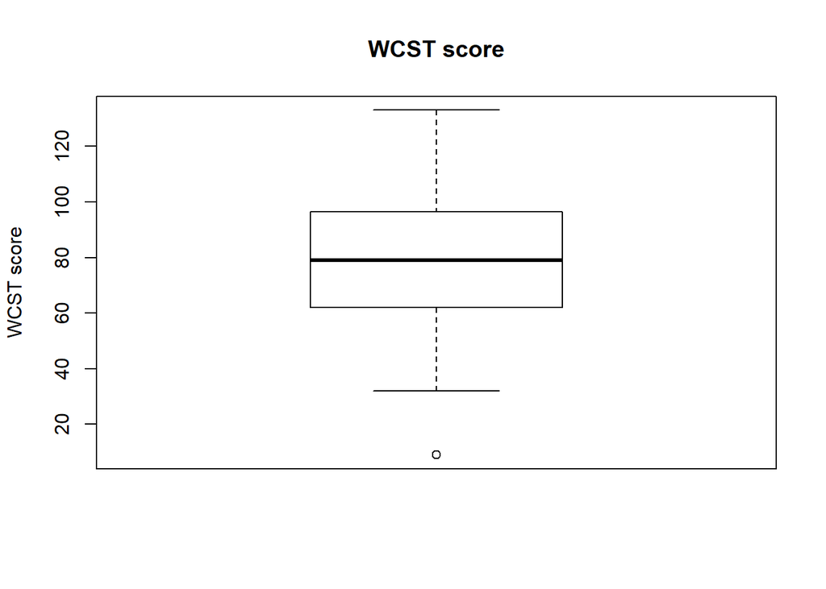

```r
boxplot(SCH_full$WCST_score, data=SCH_full, ylab="WCST score", main="WCST score")
```

There is one outlier in our WCST data.

Visualizing SSRT outliers in boxplot

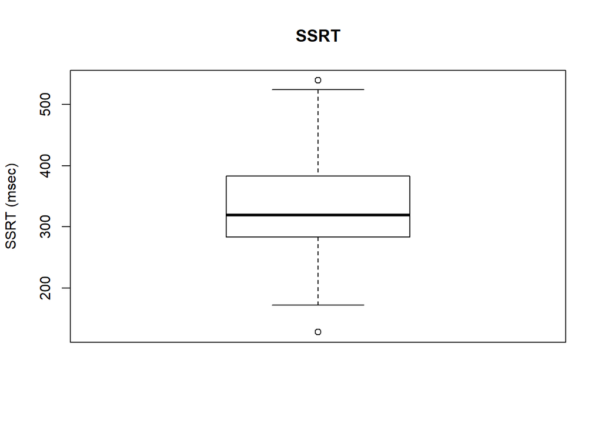

```r
boxplot(SCH_full$SSRT, data=SCH_full, ylab="SSRT (msec)", main="SSRT")
```

There are two outliers in the SSRT data.

Discarding both SSRT and WCST_score outliers

```r
summary(SCH_full)
```

```
##      JELIGE        WCST_score        WCST_cat          SSRT
##  Min.   :101.0   Min.   :  9.00   Min.   :1.000   Min.   :128.3
##  1st Qu.:112.5   1st Qu.: 62.00   1st Qu.:1.000   1st Qu.:283.4
##  Median :128.0   Median : 79.00   Median :1.000   Median :319.2
##  Mean   :220.9   Mean   : 80.13   Mean   :1.404   Mean   :328.2
##  3rd Qu.:142.5   3rd Qu.: 96.50   3rd Qu.:2.000   3rd Qu.:383.1
##  Max.   :804.0   Max.   :133.00   Max.   :2.000   Max.   :539.1
##     Raven_IQ
##  Min.   : 66.00
##  1st Qu.: 83.50
##  Median : 92.00
##  Mean   : 93.96
##  3rd Qu.:102.00
##  Max.   :135.00
```

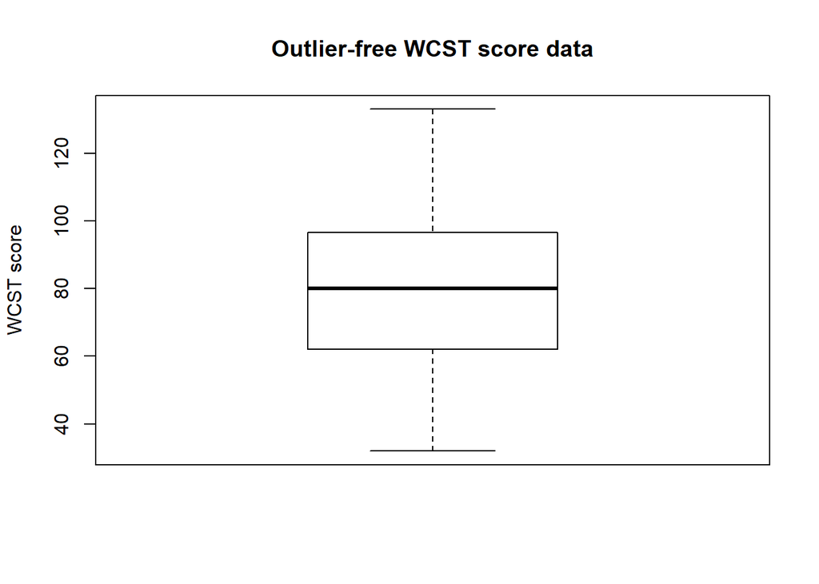

```r
#bench for WCST_score outliers
bench_WCST = 62.00 - 1.5*IQR(SCH_full$WCST_score)
#benches for SSRT outliers
bench_SSRT_upper= 383.1 + 1.5*IQR(SCH_full$SSRT)
bench_SSRT_lower= 283.4 - 1.5*IQR(SCH_full$SSRT)

SCH_SSRT <- subset(SCH_full, SSRT<bench_SSRT_upper & SSRT>bench_SSRT_lower & WCST_score>bench_WCST)
boxplot(SCH_SSRT$WCST_score, ylab="WCST score", main = "Outlier-free WCST score data")
```

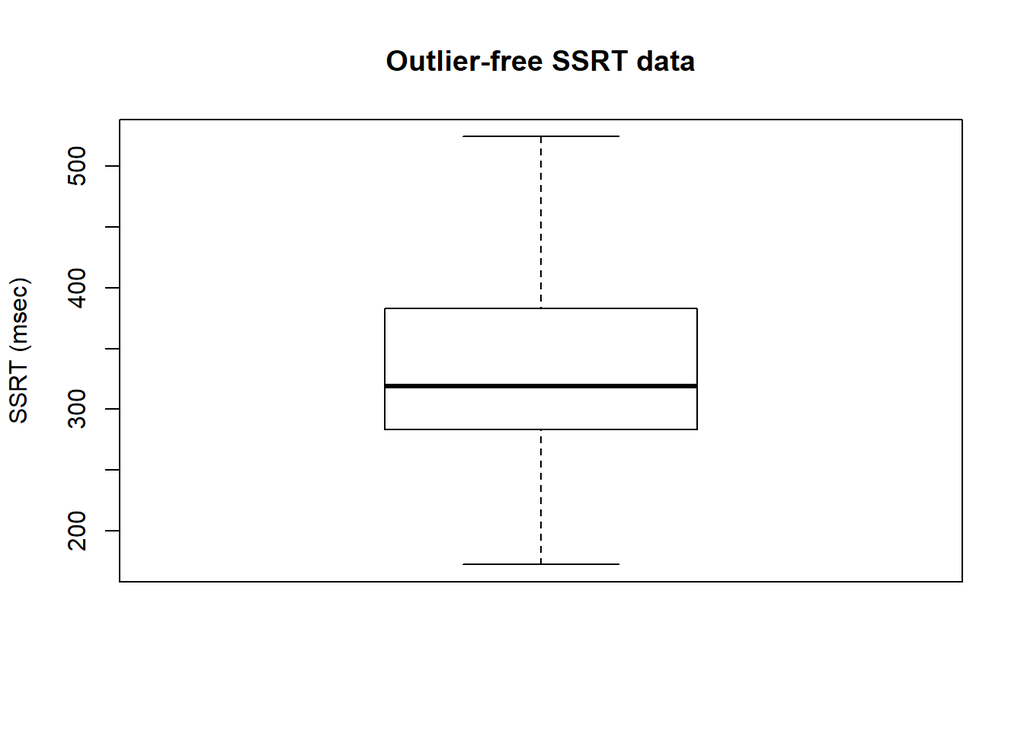

```r
boxplot(SCH_SSRT$SSRT, ylab= "SSRT (msec)", main = "Outlier-free SSRT data")
```

As we can see, the outliers are gone.

Normality of outlier-free WCST_score data

```r
shapiro.test(SCH_SSRT$WCST_score)
```

```
##
##  Shapiro-Wilk normality test
##
## data:  SCH_SSRT$WCST_score
## W = 0.98339, p-value = 0.7685
```

Our WCST_score data is normally distributed (p>0.05).

Visualizing distribuion of WCST_score data with histogram and normal curve

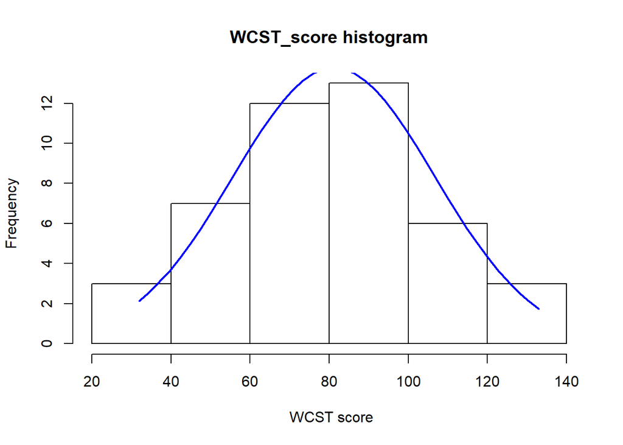

```r
histogram <- hist(SCH_SSRT$WCST_score, plot=TRUE, main="WCST_score histogram", xlab=" WCST score" )
xfit<-seq(min(SCH_SSRT$WCST_score),max(SCH_SSRT$WCST_score),length=40)
yfit<-dnorm(xfit,mean=mean(SCH_SSRT$WCST_score),sd=sd(SCH_SSRT$WCST_score))
yfit <- yfit*diff(histogram$mids[1:2])*length(SCH_SSRT$WCST_score)
lines(xfit, yfit, col="blue", lwd=2)
```

Normality of outlier-free SSRT data

```r
shapiro.test(SCH_SSRT$SSRT)
```

```
##
##  Shapiro-Wilk normality test
##
## data:  SCH_SSRT$SSRT
## W = 0.98016, p-value = 0.6398
```

The SSRT data is also normally distributed (p>0.05).

Visualizing distribuion of SSRT data with histogram and normal curve

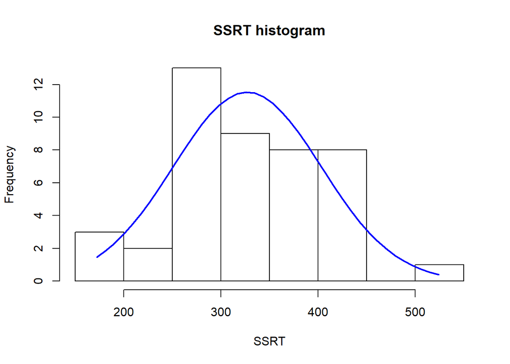

```r
histogram <- hist(SCH_SSRT$SSRT, plot=TRUE, main="SSRT histogram", xlab="SSRT" )
xfit<-seq(min(SCH_SSRT$SSRT),max(SCH_SSRT$SSRT),length=40)
yfit<-dnorm(xfit,mean=mean(SCH_SSRT$SSRT),sd=sd(SCH_SSRT$SSRT))
yfit <- yfit*diff(histogram$mids[1:2])*length(SCH_SSRT$SSRT)
lines(xfit, yfit, col="blue", lwd=2)
```

## 3. Hypotheses and investigation

Hypothesis 1: Subject in the higher performing WCST group will have higher Raven intelligence quotients compared to the lower performing WCST group.

Hypothesis 2: There is a negative correlation between WCST scores (better executive functions) and SSRT (faster reaction times in the Stop signal paradigm).

### 3.1. Investigating Hypothesis 1 with an independent samples t-test

#### 3.1.1. Checking for equal variances in the two WCST groups

```r
var.test(Raven_IQ ~ WCST_cat, data=SCH_full, alternative = "two.sided")
```

```
##
##  F test to compare two variances
##
## data:  Raven_IQ by WCST_cat
## F = 0.64066, num df = 27, denom df = 18, p-value = 0.2878
## alternative hypothesis: true ratio of variances is not equal to 1
## 95 percent confidence interval:
##  0.2593126 1.4678684
## sample estimates:
## ratio of variances
##          0.6406615
```

There is no significant difference between the variances of the two WCST groups (p>0.05), hence we can carry out the independent samples t-test (the normal distribution of Raven IQ was established earlier).

#### 3.1.2. Conducting the independent samples t-test

```r
t.test(SCH_Raven$Raven_IQ~SCH_Raven$WCST_cat)
```

```
##
##  Welch Two Sample t-test
##
## data:  SCH_Raven$Raven_IQ by SCH_Raven$WCST_cat
## t = -1.1431, df = 28.613, p-value = 0.2625
## alternative hypothesis: true difference in means is not equal to 0
## 95 percent confidence interval:
##  -14.451661   4.092986
## sample estimates:
## mean in group 1 mean in group 2
##        90.92593        96.10526
```

There is no significant difference between the two WCST groups with regards to Raven IQ score.

#### 3.1.3. Visualizing Raven IQ in the two WCST groups

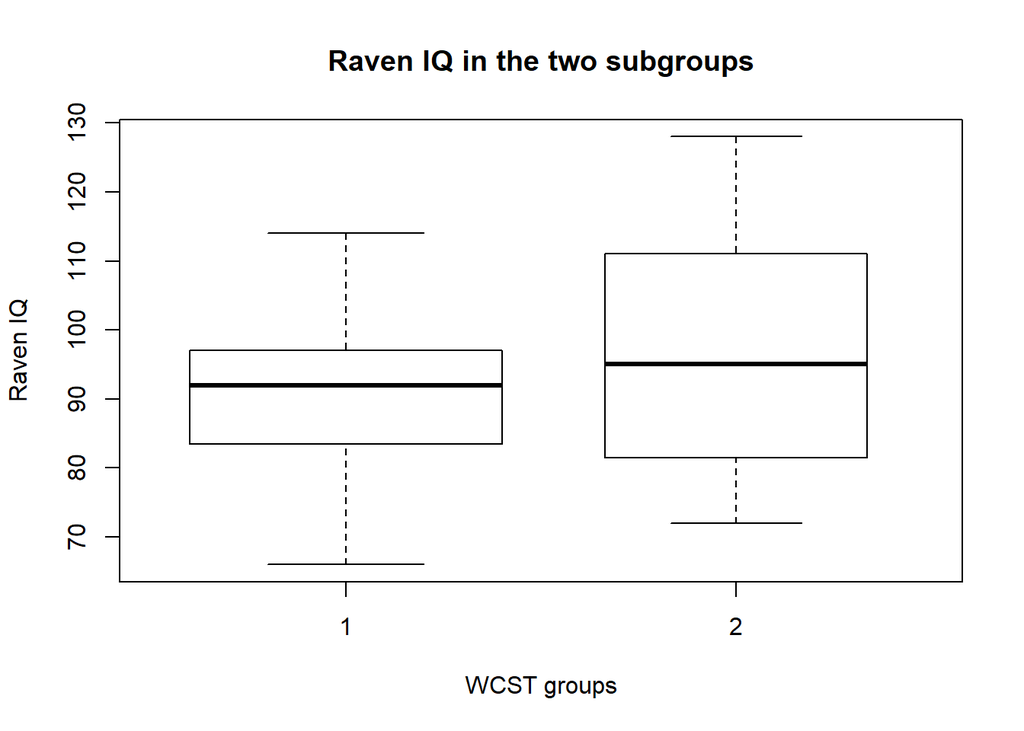

```r
boxplot(Raven_IQ~WCST_cat,data=SCH_Raven, main="Raven IQ in the two subgroups",
        xlab="WCST groups", ylab="Raven IQ", varwidth=TRUE)
```

### 3.2. Investigating the relationship between WCST score and Stop Signal reaction times (SSRT) with Pearson correlation

#### 3.2.1. Conducting the Pearson correlation test

```r
cor_res <- cor.test(SCH_SSRT$WCST_score, SCH_SSRT$SSRT, method= "pearson")
cor_res
```

```
##
##  Pearson's product-moment correlation
##
## data:  SCH_SSRT$WCST_score and SCH_SSRT$SSRT
## t = 0.050159, df = 42, p-value = 0.9602
## alternative hypothesis: true correlation is not equal to 0
## 95 percent confidence interval:
##  -0.2898068  0.3039215
## sample estimates:
##         cor
## 0.007739409
```

There is no significant correlation between WCST scores and SSRT (p>0.05).

#### 3.2.2. Visualizing the relationship between WCST scores and SSRT

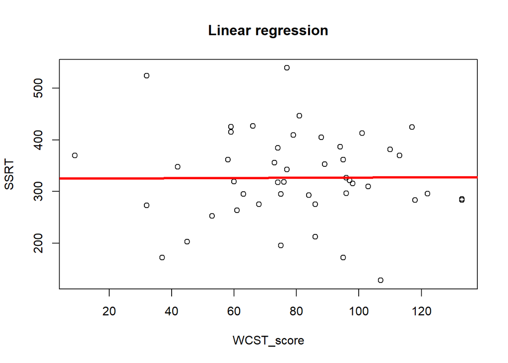

```r
# Linear model
plot(SSRT ~ WCST_score, SCH_full, main="Linear regression")
regrline <- lm(SSRT ~ WCST_score, SCH_SSRT)
abline(regrline, lwd=3, col='red')
```

```r
summary(regrline)
```

```
##
## Call:
## lm(formula = SSRT ~ WCST_score, data = SCH_SSRT)
##
## Residuals:
##      Min       1Q   Median       3Q      Max
## -154.935  -44.679   -7.661   55.001  198.522
##
## Coefficients:
##              Estimate Std. Error t value Pr(>|t|)
## (Intercept) 325.13806   39.19702   8.295 2.18e-10 ***
## WCST_score    0.02312    0.46103   0.050     0.96
## ---
## Signif. codes:  0 '***' 0.001 '**' 0.01 '*' 0.05 '.' 0.1 ' ' 1
##
## Residual standard error: 77.01 on 42 degrees of freedom
## Multiple R-squared:  5.99e-05,   Adjusted R-squared:  -0.02375
## F-statistic: 0.002516 on 1 and 42 DF,  p-value: 0.9602
```

```r
SCH_SSRT$predicted <- predict(regrline)   # The predicted values
SCH_SSRT$residuals <- residuals(regrline) # The residual values
# Look at the actual, predicted, and residual values
SCH_SSRT %>% select(SSRT, predicted, residuals) %>% head()
```

```
## # A tibble: 6 x 3
##    SSRT predicted  residuals
##   <dbl>     <dbl>      <dbl>
## 1 275.2  326.7106  -51.51056
## 2 352.7  327.1962   25.50382
## 3 386.5  327.3118   59.18820
## 4 424.3  327.8437   96.45633
## 5 172.4  327.3349 -154.93493
## 6 203.1  326.1787 -123.07868
```

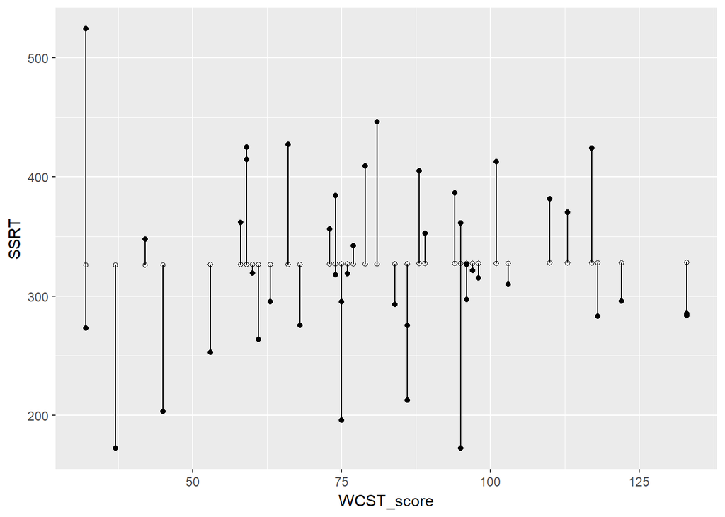

```r
#ggplot(SCH_SSRT, aes(x = WCST_score, y = SSRT)) +
  #geom_point()  # Plot the actual points
#ggplot(SCH_SSRT, aes(x = WCST_score, y = SSRT)) +
  #geom_point() +
  #geom_point(aes(y = predicted), shape = 1)  # Add the predicted values
#connect the actual data points with their corresponding predicted value:
ggplot(SCH_SSRT, aes(x = WCST_score, y = SSRT)) +
  geom_segment(aes(xend = WCST_score, yend = predicted)) +
  geom_point() +
  geom_point(aes(y = predicted), shape = 1)
```

Our linear model proves to be non-significant and looking at the residuals, a poor fit.

## 4. Conclusion

In conclusion, neither of the hypotheses were confirmed. There was no difference between the two executive function-based subgroups with regards to fluid intelligence, and I did not find a correlation between set shifting ability (as measured by the WCST) and behavioural inhibition (as measured by the stop singla task). This could be a result of the relatively small sample size, or the fact that we investigated and compared schizophrenic patients to each other for the lack of a control group.